# Second Thomas Shoal Forecast

Denis Willett

August 29, 2014

## Question (from GJP)

**#1394** Before 31 December 2014, will China seize control of Second Thomas Shoal?

### Interpretation Clarifications (from GJP)

Second Thomas Shoal is a low-tide coral reef located in the South China Sea, approximately 105 nautical miles from the Philippines’ Palawan Island. Known as Ayungin in the Philippines and Ren’ai Reef in China, the shoal is a strategic gateway to oil and natural gas deposits and is a potential flashpoint for conflict in the region. The shoal is claimed by the Philippines to be within its 200 mile exclusive economic zone and declared by China as part of an area over which it asserts “indisputable sovereignty” (http://www.aspmedia.org/2013/blogs/second-thomas-shoal-likely-the-next-flashpoint-in-the-south-china-sea/ ; http://uk.reuters.com/article/2014/03/10/china-philippines-idUKL3N0M72VO20140310 ). For the purposes of this question, *“seizing control” refers to Chinese armed forces taking sole control of the shoal and surrounding waters. “Sole control” requires the exit of currently stationed Filipino armed forces. Whether the Filipino armed forces leave on their own volition or are forced to leave is irrelevant for the outcome, as is the means by which China achieves control (e.g., invasion, expulsion, blockade of supply delivery), so long as China has sole control of the shoal and surrounding waters. Forecasting problem outcomes will be determined by the Administrator using credible open sources, such as Reuters, BBC, Associated Press, or question-specific sources (e.g., Freedom House). Administrator reserves judgment as to which sources are deemed credible. If nothing is reported in a credible open source, then the “status quo” outcome (i.e., China has not seized control of Second Thomas Shoal) typically will be assumed. In cases of substantial controversy or uncertainty about an outcome or the credibility of a source, Administrator may take various steps, such as referring the question to outside subject matter experts or declaring the question invalid/void. “Before” should be interpreted to mean at or prior to the end (23:59:59 ET) of the previous day. For example, “before 10 Oct” means any time up to 23:59:59 ET on 9 Oct.

### Initial Assessment

Date: August 29<sup>th</sup>, 2014

### Schedule

Due: December 31<sup>st</sup>, 2014

Milestones: 122 days left. Revisit on a monthly basis to double check assumptions and models.

### Background

Second Thomas Shoal is a reef upon which the Philippines sunk a ship (in really bad conditions see the [NY Times article](http://www.nytimes.com/2014/04/01/world/asia/beijing-and-manila-in-dispute-over-reef.html?_r=0) for a picture) and occupied by 10 Phillipine Marines who live off of spearfishing and the occasional shipments from the Phillipines. It is one of many shoals and islands that are part of the Spratly Islands Group (Figure 1 and Figure 2).

> **Figure 1:** Location of the Second Thomas Shoal in the South China Sea

[figure not shown]

> **Figure 2:** Location of the Spratly Islands and claimed territories

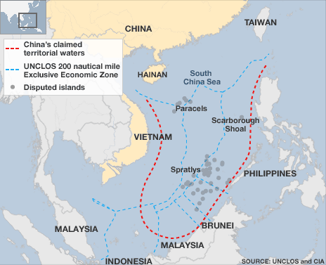

> from: [BBC South China Sea Dispute](http://www.bbc.com/news/world-asia-pacific-13748349)

It seems that the Second Thomas Shoal is a flash point and disputed territory for three reasons:

- Historical claims
- The possibility of natural resources (hydrocarbons; see Figure 3 in Natural Resources Section)
- Power projection/national pride in the Pacific

The following analysis will focus on those three primary reasons (historical claims, natural resources, power projection) and seek to determine their influence on the outcome.

# CHAMPS-KNOW Analysis

## Comparison Classes (Base Rates):

### Historical Claims and Acquisitions

The relevant history related to the Second Thomas Shoal really began post WWII. Conflicts have accelerated only in the last two decades with Chinese acquisitions and actions (Table 1). Most notably China siezed control of the Scarborough Shoal in 2012. Despite international agreements with the Philippines and US to leave the Shoal, the Chinese navy continues to occupy it<sup>[1](http://www.aspmedia.org/2013/blogs/second-thomas-shoal-likely-the-next-flashpoint-in-the-south-china-sea/)</sup>. The Chinese evidently see that as a success story and there have been calls within China to expand the same strategy to other members of the Spratly Islands<sup>[1](http://www.aspmedia.org/2013/blogs/second-thomas-shoal-likely-the-next-flashpoint-in-the-south-china-sea/)</sup>.

Table 1: Significant events in the South China Sea

| Dates | Events |
| --- | --- |
| 1946 | After Japanese surrender in WWII, Chinese Nationalist Government draws nine-dash line around South China Sea claiming territory |
| 1994 | United Nations Convention on the Law of the Sea (UNCLOS) defines territorial waters and exclusive economic zones |
| 1995 | China takes control of Mischief Reef (also part of the Spratly Islands) |
| 1999 | Philippines sinks Sierra Madre warship on Second Thomas Shoal |
| 2010 | Philippines awards gas exploration contracts for Reed Bank (just north of Spratly Islands) but exploration is stopped by Chinese ships |
| 2012 | China takes control of Scarborough Shoal |
| 2014 | China Installs Oil Rig in Paracel Islands |

### Natural Resources

Most news articles discuss purported potential of areas in the South China Sea for natural resources, namely hydrocarbons. While each country is undoubtedly relying on internal, private estimates of potential, the most recent publicly available analysis seems to be [Owen and Schofield 2012](http://www.sciencedirect.com/science/article/pii/S0308597X11001953#). What follows are the salient points from that article.

- The Scarborough Shoal, a site of conflict in 2012 does not sit on hydrocarbon reserves (Figure 3).

> **Figure 3:** Hydrocarbons and Territorial Claims. Numbers on map correspond to numbered basins in table below. The Second Thomas Shoal is on the South China Sea Platform. *Mboe* denotes Million barrels of oil equivalent, a unit of energy used for comparing different hydrocarbons.

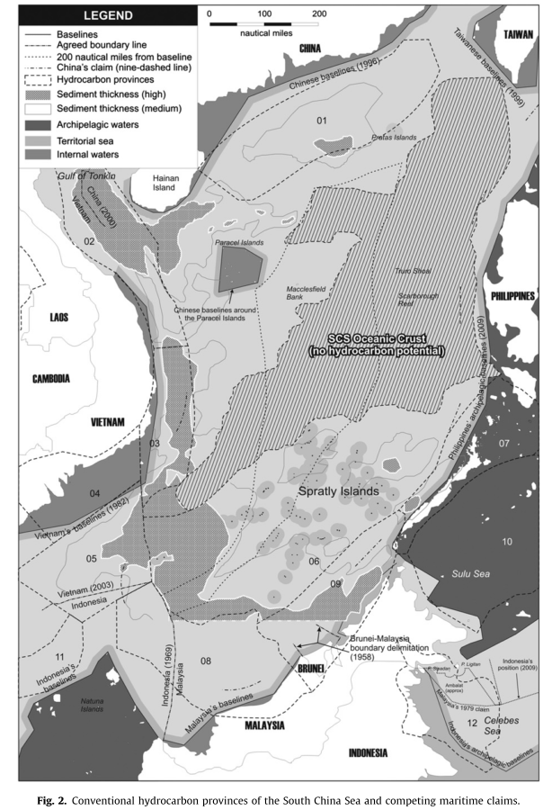

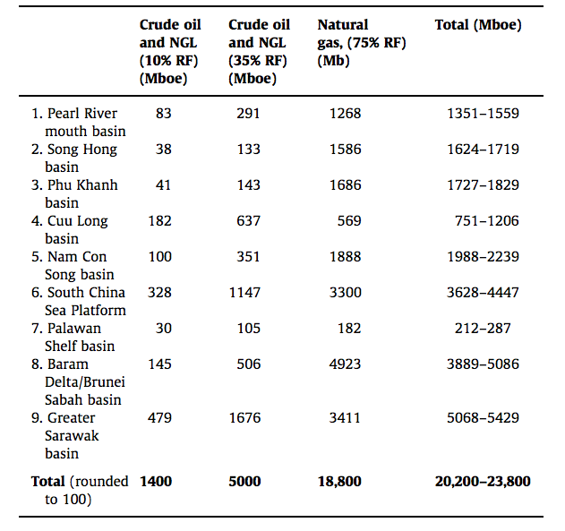

> As a tangent, these gas hydrate (particularly methane hydrate) structures are hugely important irrespective of their energy potential as they play a major role in climate change, particularly in permafrost regions and due to their instability under increasing temperature regimes.
- China has become a major importer of petroleum, but not of natural gas (although it imports a little; Figure 4)

> **Figure 4:** Import and Export trends in the South China Sea region.

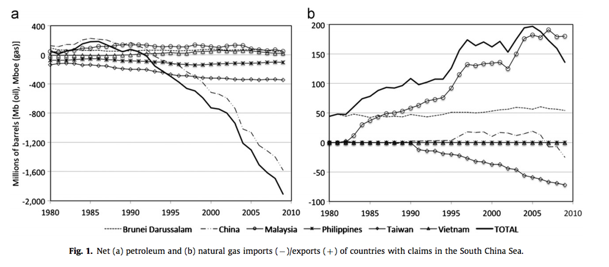

> from: [Owen and Schofield 2012](http://www.sciencedirect.com/science/article/pii/S0308597X11001953#)
- A highly optimistic estimate puts the ultimate recoverable reserve in the South China Sea at 6000 Mb of conventional crude oil. This estimate (from [Owen and Schofield 2012](http://www.sciencedirect.com/science/article/pii/S0308597X11001953#) ) is much larger than estimates from many other countries (including the [USGS report in 2010](http://pubs.usgs.gov/fs/2010/3015/pdf/FS10-3015.pdf) ) but much more conservative than China which is evidently notorious for producing wildly optimistic estimates of hydrocarbon resources.
- Even if all disputes were resolved and development began in 2012 (when the article was published), production would not begin until after 2020 and would not peak until the 2030s at 200 Mb/year for crude oil and 1015 Mboe/year for natural gas (Figure 5).

> **Figure 5:** Production estimates for South China Sea region if disputes were resolved and production began in 2012.

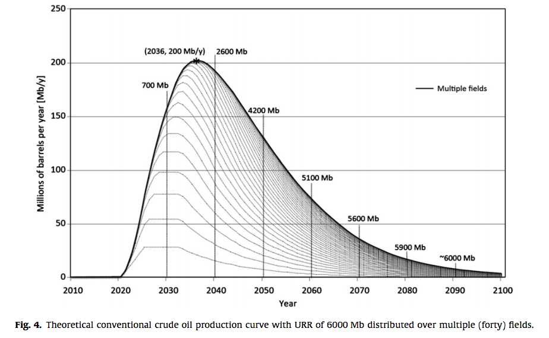

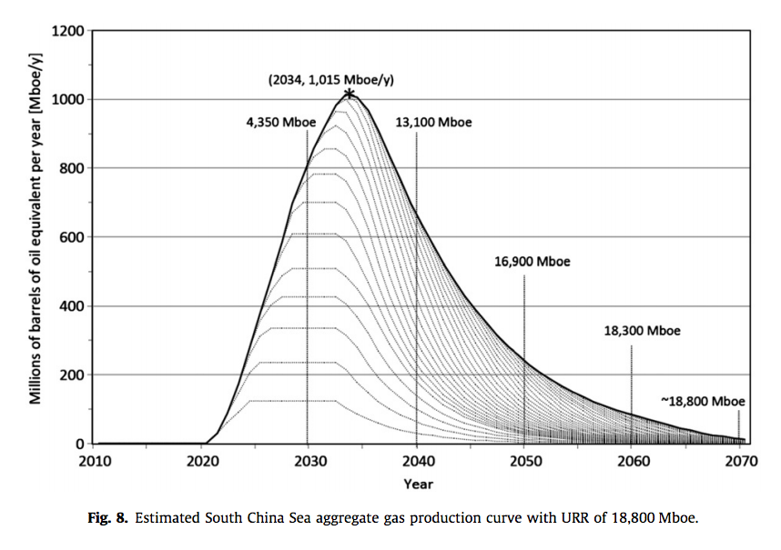

> from: [Owen and Schofield 2012](http://www.sciencedirect.com/science/article/pii/S0308597X11001953#)
- The resources in the South China Sea would have little impact on China and a large impact on the Phillipines (Figure 6).

From Owen and Schofield 2012:

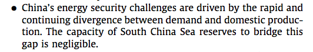

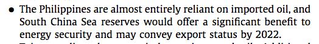

> **Figure 6:** Projected impact of crude oil reserves for countries with claims in the South China Sea.

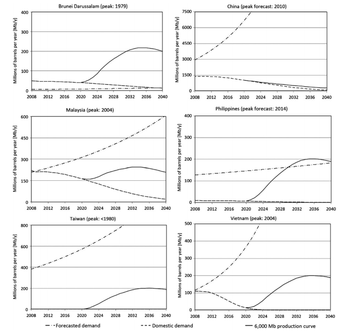

> from: [Owen and Schofield 2012](http://www.sciencedirect.com/science/article/pii/S0308597X11001953#)

Conclusions from the Owen and Schofield 2012:

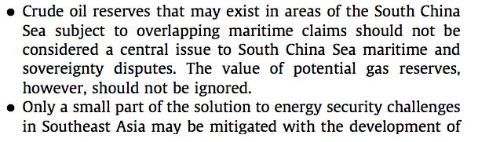

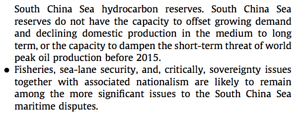

### Power Projections and National Pride

The Chinese promote control of the shoal as part of national sovereignity, while the philippines see it as a point of pride to resist the chinese. In terms of being actually capable of implementing and/or resisting power plays in the South China Sea, China has orders of magnitude more naval power than the Philippines<sup>[2](http://www.globalfirepower.com/countries-comparison-detail.asp?form=form&country1=China&country2=Philippines&Submit=Compare+Countries)</sup>. The Philippines must rely on United Nations protocols and a mutual defense treaty with the United States to have any chance at resisting incursions by the Chinese.

## Hunt for Right Information:

Good Background:

- [Brookings Institute Background on Chinese claims](http://www.brookings.edu/research/opinions/2014/02/06-us-china-nine-dash-line-bader)
- [Georgetown University analysis on Second Thomas Shoal](http://www.aspmedia.org/2013/blogs/second-thomas-shoal-likely-the-next-flashpoint-in-the-south-china-sea/)
- [Reuters Recent Conflict Overview](http://uk.reuters.com/article/2014/03/10/china-philippines-idUKL3N0M72VO20140310)
- [Diplomat Overview](http://thediplomat.com/2014/04/second-thomas-shoal-the-new-battleground/)
- [BBC Background](http://www.bbc.com/news/world-asia-pacific-13748349)

## Adjust and Update Information:

Check in weekly for updates. The first steps of Chinese control will be more conflicts with Philippine ships, then a surrounding/blockading of the shoal.

## Modeling

Not Applicable at this time…

## Post Mortem Analysis

Not yet…

## Select the right level of effort.

Question is interesting primarily because, prior to reading the background on the topic, I had no idea what the Second Thomas Shoal was.

## Power players and preferences

| Player | Preferences |
| --- | --- |
| China | Claim Second Thomas Shoal |
| Philippines | Occupy Second Thomas Shoal |
| USA | Support the Philippines |

## Norms, Rules, Protocols

While international maritime law nominally applies, the Chinese have ignored it in the past (particularly at Scarborough Shoal)

Nominally applicable rules include the United Nations Convention on Laws of the Sea (UNCLOS) which was implemented in 1994 and established boundaries for territorial waters. It places the Second Thomas Shoal in the exclusive economic zone of the Philippines.

Also applicable is a mutual defense treaty the US signed with the Philipines that designates support for the Philippine navy, but seems not to explicitly require a US naval response to a Chinese Incursion. In 2012, for example, the US sent an aircraft carrier to the region to show support for the Philippines during the Scarborough Shoal incident, but did not take any action once China reneged on agreements and occupied the shoal.

## Other Perspectives

Most news reports agree that China will take control of the shoal at some point.

## Wildcards

Not likely, but then they never are…

# Assessment and Forecast

Although much hyped (most news articles report resources as underlying the dispute), natural resources (hydrocarbons) seem to play only a minor role in the dispute. That being said, China will likely use its inflated estimates of production in any rhetorical buildup to future occupation. The media will likely continue to report on the role of natural resources as well. If anything, natural resources should be a factor for the Philippines as it stands the most to gain from control of the territory, but given its unbalanced military standing in the region, it can do little against Chinese incursions.

Barring some drastic intervention by the United States (which we seem little inclined to do given our occupations elsewhere), it seems likely that China will come to control the South China Sea in the next decade. The question then becomes whether China will control the Second Thomas Shoal before December 31st of this year.

It does seem likely that China will control the shoal before the end of the year. The Philippines will likely send resupplies to the marines, there will likely be a skirmish of some sort involving China’s ‘Sovereignity Patrols’ and China will end up sitting on or around the shoal with its ships. The real trick will be in seeing how well China times its control and manages international reactions which will influence the long term outcome more than its initial occupation.

Initial probability of Chinese control by the end of the year will be placed at 60%, to be adjusted over the weeks to come (likely upward)